# EMD 539 Exercise using Google Trend and Google Correlate

Dan Weinberger and Kayoko Shioda

March 4, 2019

## Part 1. Combining syndromic surveillance and search data to track covid-19

See slides

## Part 2: Generate predictions for diarrhea at NYC EDs (Google correlate)

The Google correlate public page is no longer active. But when it was, you could upload any time series and obtain time series of search volume for the top 100 best-correlated search terms

Today, we will use syndromic disease data on diarrhea from NYC EDs, saved in `nyc diarrhea syndromic raw.csv`.

Here are steps:

1. Create age-stratified weekly time series data on diarrhea syndromic visits to NYC EDs.
2. Go to Google Correlate and obtain time series for 100 top-correlated search terms.
3. Choose relevant search terms from top 100 search terms.
4. Fit negative binomial regression models with or without a relevant search term, controlling for seasonality and long-term trend, to the “training” data. Generate predictions for the rest of the data.
5. Calculate “average” predictions using AIC model weight.

### Part 2-1: Create age-stratified weekly time series data on diarrhea

(setup not shown)

```r
diar.18.64<-read.csv('./Data/nyc diarrhea 18_64.csv')
```

### Part 2-2: Obtain time series for 100 top-correlated search terms from Google Correlate

Let’s import a generated csv file for the data on top 100 search terms correlated with diarrhea data from NYC EDs, and look at variable names.

```r
# Import the csv file
corr1 <- read.table('./Data/correlate-nyc_diar_18_64y_log.csv', sep=',', skip=11, header=T)

# Look at variable names
names(corr1) # Top 100 search terms
```

```
##   [1] "Date"                       "nyc.diar.18_64y.log"
##   [3] "grapefruit"                 "gi.virus"
##   [5] "viral.gastroenteritis"      "mountain.forecast"
##   [7] "punta"                      "orange.calories"
##   [9] "full.year"                  "tulum.mexico"
##  [11] "cancun.to.playa.del.carmen" "flights.to.west.palm"
##  [13] "navel.orange"               "flight.to.florida"
##  [15] "flights.to.cancun"          "englewood.florida"
##  [17] "cat.in.heat"                "roth.vs.traditional"
##  [19] "flights.to.west.palm.beach" "gi.bug"
##  [21] "rsw"                        "orange.nutrition"
##  [23] "flights.to.orlando"         "flights.to.key.west"
##  [25] "flights.to.florida"         "water.heater"
##  [27] "sauna"                      "cherry.blossom.season"
##  [29] "a.cat.in.heat"              "resort.punta.cana"
```

[output cut: 36 more lines]

### Part 2-3: Choose relevant search terms

Among these top 100 search terms, extract just the relevant search terms.

```r
# The following terms will be kept in a new dataset.
# (Emetrol is a nausea treatment and augmentin is an antibiotic.)
keep.terms <- c("gi.virus", "viral.gastroenteritis", "gi.bug", "emetrol", "augmentin", "stomach.virus")

# Only keep the relevant search terms and the "Date" variable in a new dataset.
corr2 <- corr1[,c('Date', keep.terms)]
corr2$Date<-as.Date(corr2$Date)
```

Make time series plots for the relevant search terms.

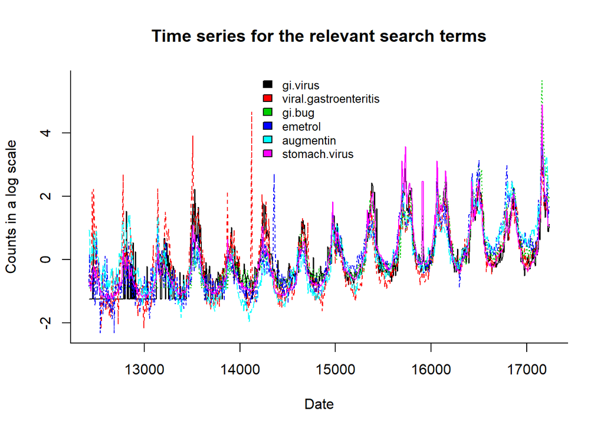

```r
# Change the class of the "Date" variable from factor to Date.

# Make time series plots
par(mfrow=c(1,1))
matplot(x=as.Date(corr2$Date),
        y=corr2[,-1],  #plot everything except first column
        type='l', #line plot
        bty='l', #turn off top and right border
        main="Time series for the relevant search terms", ylab="Counts in a log scale", xlab="Date")
legend("top", colnames(corr2)[-1], col=seq_len(ncol(corr2)-1), cex=0.8, fill=seq_len(ncol(corr2)-1), bty="n")
```

Merge the original diarrhea data with the search term data.

```r
# Time periods are different in these data, so the data have to be merged by date.
summary(as.Date(diar.18.64[,1]))
```

```
##         Min.      1st Qu.       Median         Mean      3rd Qu.
## "2006-01-08" "2009-01-16" "2012-01-25" "2012-01-25" "2015-02-02"
##         Max.
## "2018-02-11"
```

```r
summary(corr2$Date)
```

```
##         Min.      1st Qu.       Median         Mean      3rd Qu.
## "2004-01-04" "2007-04-22" "2010-08-08" "2010-08-08" "2013-11-24"
##         Max.
## "2017-03-12"
```

```r
# Define column names for the "diar.18.64" dataset
diar.18.64 <- as.data.frame(diar.18.64) # diar.18.64 is a matrix, so change it to data frame
colnames(diar.18.64) <- c("Date", "diar.18.64")
```

```r
# Change variable types
str(diar.18.64)
```

```
## 'data.frame':    632 obs. of  2 variables:
##  $ Date      : Factor w/ 632 levels "2006-01-08","2006-01-15",..: 1 2 3 4 5 6 7 8 9 10 ...
##  $ diar.18.64: int  538 482 456 482 460 418 491 502 527 555 ...
```

```r
diar.18.64$Date <- as.Date(diar.18.64$Date)
diar.18.64$diar.18.64 <- as.numeric(as.character(diar.18.64$diar.18.64))
```

```r
# Merge two datasets by date
corr3 <- merge(diar.18.64, corr2, by = "Date")
```

```r
# Check
head(corr3)
```

```
##         Date diar.18.64 gi.virus viral.gastroenteritis gi.bug emetrol
## 1 2006-01-08        538    0.029                 0.142 -0.898  -0.399
## 2 2006-01-15        482    0.183                -0.700 -0.898  -0.313
## 3 2006-01-22        456   -1.259                 0.008 -0.898  -0.611
## 4 2006-01-29        482   -1.259                 0.027 -0.898   0.013
## 5 2006-02-05        460    0.096                -0.120 -0.898   0.278
## 6 2006-02-12        418   -0.500                 0.295 -0.898  -0.169
##   augmentin stomach.virus
## 1    -0.031        -0.147
## 2    -0.374        -0.380
## 3     0.096        -0.505
## 4    -0.079        -0.450
## 5    -0.026        -0.449
## 6     0.046        -0.263
```

```r
summary(corr3$Date)
```

```
##         Min.      1st Qu.       Median         Mean      3rd Qu.
## "2006-01-08" "2008-10-24" "2011-08-10" "2011-08-10" "2014-05-26"
##         Max.
## "2017-03-12"
```

### Part 2-4a: Generate prediction for the diarrhea data (Baseline comparison model)

OK, now the data have been prepared. Let’s first make a simple regression model with no seaarch terms. We will control for seasonality and long-term trends using harmonic terms and linear trend term. We will fit a negative binomial regression using `glm.nb`. This will be a baseline comparison model.

```r
# Create a linear trend term
corr3$t <- 1:nrow(corr3)

# Create harmonic terms to control for annual seasonality
corr3$sin52 <- sin(2*pi*corr3$t/52.1429)
corr3$cos52 <- cos(2*pi*corr3$t/52.1429)

# Create harmonic terms to control for biannual seasonality
corr3$sin26 <- sin(2*pi*corr3$t*2/52.1429)
corr3$cos26 <- cos(2*pi*corr3$t*2/52.1429)
```

We will fit the model to the “training” data, and generate prediction for the rest of the data.

```r
# Create a "training" data
corr3$training.data <- corr3$diar.18.64
corr3$training.data[(nrow(corr3)-260):nrow(corr3)] <- NA # Hold out last 5 years of data to be used for evaluation

# Check
corr3$training.data
```

```
##   [1] 538 482 456 482 460 418 491 502 527 555 553 609 559 532 505 477 419
##  [18] 431 403 422 384 377 351 348 344 325 326 346 361 358 388 355 357 314
##  [35] 358 347 353 337 326 322 306 336 386 359 403 412 480 465 579 545 682
##  [52] 644 520 504 546 506 522 568 550 603 572 560 527 454 484 482 464 435
##  [69] 333 403 373 357 348 358 373 328 369 377 337 361 351 335 331 348 348
##  [86] 366 371 350 314 312 346 336 313 302 276 309 315 265 356 395 390 456
## [103] 622 595 674 561 566 653 662 590 554 509 525 491 444 473 503 477 455
## [120] 456 472 356 423 382 388 379 467 467 454 473 492 457 443 413 411 418
## [137] 404 413 425 437 415 353 346 358 319 333 354 421 393 413 522 624 639
## [154] 719 647 664 683 615 619 604 605 566 564 550 537 476 487 496 511 473
## [171] 460 472 687 572 479 578 571 554 481 458 406 382 374 395 387 373 357
## [188] 430 413 380 385 408 362 336 325 338 331 357 336 320 407 419 359 431
## [205] 412 424 507 595 591 777 817 804 689 758 722 687 618 665 612 570 492
## [222] 510 416 498 487 441 452 532 442 478 449 441 452 484 524 491 461 474
## [239] 439 417 451 433 438 444 380 418 361 321 335 311 379 369 391 465 446
```

[output cut: 20 more lines]

Fit the baseline comparison model to the “training” data and save the results as `baseline.model`.

```r
# Baseline comparison model
baseline.model <- glm.nb(training.data ~ sin52 + cos52 + sin26 + cos26 + t, data=corr3)

# See results
summary(baseline.model)
```

```
##
## Call:
## glm.nb(formula = training.data ~ sin52 + cos52 + sin26 + cos26 +
##     t, data = corr3, init.theta = 67.42061632, link = log)
##
## Deviance Residuals:
##     Min       1Q   Median       3Q      Max
## -2.8631  -0.7560  -0.0834   0.5290   3.5339
##
## Coefficients:
##              Estimate Std. Error z value Pr(>|z|)
## (Intercept) 6.045e+00  1.466e-02 412.371  < 2e-16 ***
## sin52       1.856e-01  1.040e-02  17.848  < 2e-16 ***
## cos52       1.406e-01  1.028e-02  13.687  < 2e-16 ***
## sin26       7.087e-02  1.027e-02   6.901 5.18e-12 ***
## cos26       8.262e-02  1.033e-02   7.996 1.29e-15 ***
## t           3.406e-04  7.831e-05   4.349 1.37e-05 ***
## ---
## Signif. codes:  0 '***' 0.001 '**' 0.01 '*' 0.05 '.' 0.1 ' ' 1
##
## (Dispersion parameter for Negative Binomial(67.4206) family taken to be 1)
##
##     Null deviance: 992.62  on 322  degrees of freedom
## Residual deviance: 321.44  on 317  degrees of freedom
##   (261 observations deleted due to missingness)
## AIC: 3557
##
## Number of Fisher Scoring iterations: 1
##
##
##               Theta:  67.42
##           Std. Err.:  6.06
##
##  2 x log-likelihood:  -3542.999
```

Generate predictions and extrapolate to the testing period (last 5 years).

```r
pred.baseline <- predict(baseline.model, newdata=corr3, type='response')
```

Create a plot to compare observed vs. model-fitted values.

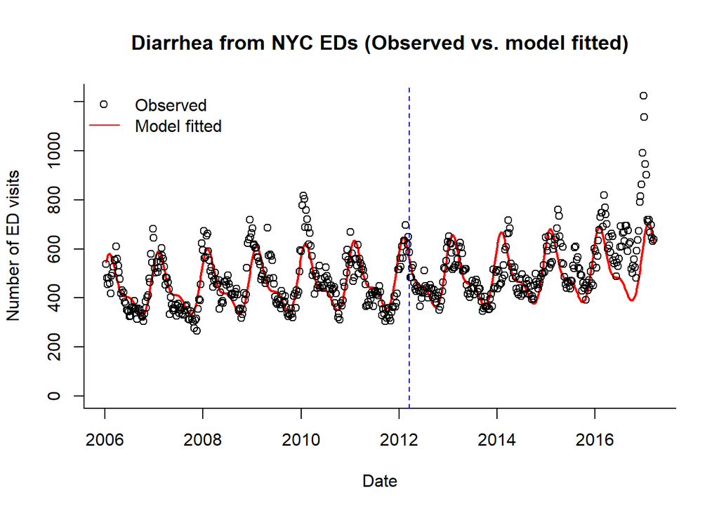

```r
plot(corr3$Date, pred.baseline, type='l', ylim=c(0, max(corr3$diar.18.64)), bty='l', col="red", lwd=2, xlab="Date", ylab="Number of ED visits", main="Diarrhea from NYC EDs (Observed vs. model fitted)") # Model fitted value
points(corr3$Date, corr3$diar.18.64) # Observed data
abline(v=corr3$Date[nrow(corr3)-260], lty=2, col="blue")
legend(x="topleft",legend = c("Observed","Model fitted"), pch=c(1, NA), lty=c(NA,1), col=c("black","red"), bty="n")
```

**Question** What do you think about the prediction by this baseline comparison model? Does it fit well to the data in the testing period (last 5 years)?

### Part 2-4b: Generate prediction for the diarrhea data (Models with search data included)

Now let’s try to improve on this baseline model using covariates (i.e., search terms). In a loop, let’s test each of the variables listed in `keep.terms`.

```r
# Create an empty list to store model results.
model.results <- vector("list", length(keep.terms))

# Fit a model with each of the variables listed in "keep.terms"
for(i in 1:length(keep.terms)){
  # Select i-th term in "keep.terms" and add it in the formula
  model.formula <- as.formula(paste0('training.data ~ sin52 + cos52 + sin26 + cos26 + t +', keep.terms[i]))
  # Fit a negative binomial regression
  model.results[[i]] <- glm.nb(model.formula, data=corr3)
}

# Combine together basic model results with other model results
model.results <- c(model.results, list(baseline.model))
```

Let’s generate predictions using each model and compare to the observed.

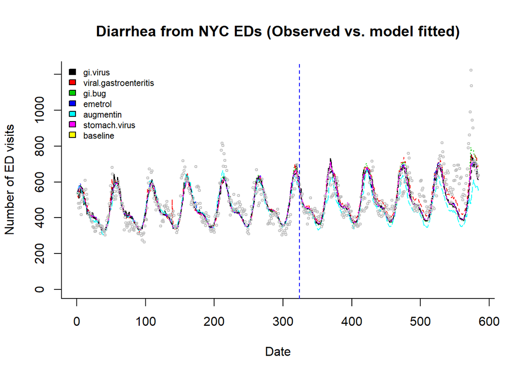

```r
# Generate predictions
model.preds <- sapply(model.results, predict, newdata=corr3, type='response', simplify='array')

# Make a plot
par(mfrow=c(1,1))
matplot(model.preds, type='l', bty='l', ylim=c(0, max(corr3$diar.18.64)), ylab="Number of ED visits", xlab="Date", main="Diarrhea from NYC EDs (Observed vs. model fitted)")
points(corr3$diar.18.64,cex=0.5, col="grey") # Observed data
abline(v=nrow(corr3)-260, lty=2, col="blue")
legend("topleft", c(keep.terms, "baseline"), col=seq_len(7), cex=0.7, fill=seq_len(7), bty="n")
```

### Part 2-5: Calculate “average” predictions using AIC model weight

Now extract the AIC score for each of the models.

AIC scores provide a measure of model fit and are penalized by model complexity. If you add a variable that increases the fit only a little bit, the AIC score might not improve because we are penalizing the model. It is calculated by calculating the model negative log-likelihood and the number of variables. Smaller numbers are better. The absolute value of AIC scores is meaningless, but a change in the AIC score of 2 or more between models is considered a meaningful improvement.

NOTE OF CAUTION: when comparing models by AIC score, you can only compare models where the outcome variable is *exactly* the same. If an observation is missing in one model but not others, they cannot be compared.

```r
# For example, let's take a look at the result from the first model (which uses "gi.virus")
summary(model.results[[1]])
```

```
##
## Call:
## glm.nb(formula = model.formula, data = corr3, init.theta = 72.24768384,
##     link = log)
##
## Deviance Residuals:
##     Min       1Q   Median       3Q      Max
## -2.7381  -0.7698  -0.0676   0.4879   3.6300
##
## Coefficients:
##              Estimate Std. Error z value Pr(>|z|)
## (Intercept) 6.086e+00  1.697e-02 358.596  < 2e-16 ***
## sin52       1.573e-01  1.189e-02  13.238  < 2e-16 ***
## cos52       9.343e-02  1.436e-02   6.504 7.82e-11 ***
## sin26       5.447e-02  1.062e-02   5.130 2.90e-07 ***
## cos26       7.451e-02  1.019e-02   7.315 2.58e-13 ***
## t           1.750e-04  8.456e-05   2.070   0.0385 *
## gi.virus    7.055e-02  1.564e-02   4.512 6.43e-06 ***
## ---
## Signif. codes:  0 '***' 0.001 '**' 0.01 '*' 0.05 '.' 0.1 ' ' 1
##
## (Dispersion parameter for Negative Binomial(72.2477) family taken to be 1)
##
##     Null deviance: 1053.99  on 322  degrees of freedom
## Residual deviance:  321.32  on 316  degrees of freedom
##   (261 observations deleted due to missingness)
## AIC: 3539.6
##
## Number of Fisher Scoring iterations: 1
##
##
##               Theta:  72.25
##           Std. Err.:  6.55
##
##  2 x log-likelihood:  -3523.56
```

```r
model.results[[1]]$aic # AIC value for this model
```

```
## [1] 3539.56
```

```r
# Extract AIC values from all models
aics <- sapply(model.results, AIC)
mods <- c(keep.terms,'baseline.model')
cbind(mods, aics)
```

```
##      mods                    aics
## [1,] "gi.virus"              "3539.56038432858"
## [2,] "viral.gastroenteritis" "3534.33098177068"
## [3,] "gi.bug"                "3553.79241361379"
## [4,] "emetrol"               "3555.36710229067"
## [5,] "augmentin"             "3538.65123522369"
## [6,] "stomach.virus"         "3556.75149030277"
## [7,] "baseline.model"        "3556.99895378978"
```

AIC values can be used to average the models together. Let’s take the AIC scores and convert them to **model weights**.

Weight for Model “m” can be calculated as follows:

$$Weight for Model_m = exp(\frac{-0.5*\Delta AIC_m}{\sum_{i=1}^{M}(-0.5*\Delta AIC_i)})$$

where M is the number of models considered (7 in our case) and $ AIC_m $ is a differece between AIC from Model m and the smallest AIC (i.e., AIC from the “best” model).

In this instance, almost all of the weight goes to the model with searches for “viral.gastroenteritis” and a small amount of weight to “gi.virus” and “augmentin”.

```r
# First, calculate delta AIC (i.e., Difference between AIC from each model and the smallest AIC)
delta.aic <- aics - min(aics)

# Calculate a weight for each model
model.weights <- round(exp(-0.5*delta.aic)/sum(exp(-0.5*delta.aic)), 3)

# Check
cbind(mods, aics,model.weights)
```

```
##      mods                    aics               model.weights
## [1,] "gi.virus"              "3539.56038432858" "0.062"
## [2,] "viral.gastroenteritis" "3534.33098177068" "0.841"
## [3,] "gi.bug"                "3553.79241361379" "0"
## [4,] "emetrol"               "3555.36710229067" "0"
## [5,] "augmentin"             "3538.65123522369" "0.097"
## [6,] "stomach.virus"         "3556.75149030277" "0"
## [7,] "baseline.model"        "3556.99895378978" "0"
```

Average the predictions from all models using AIC model weights.

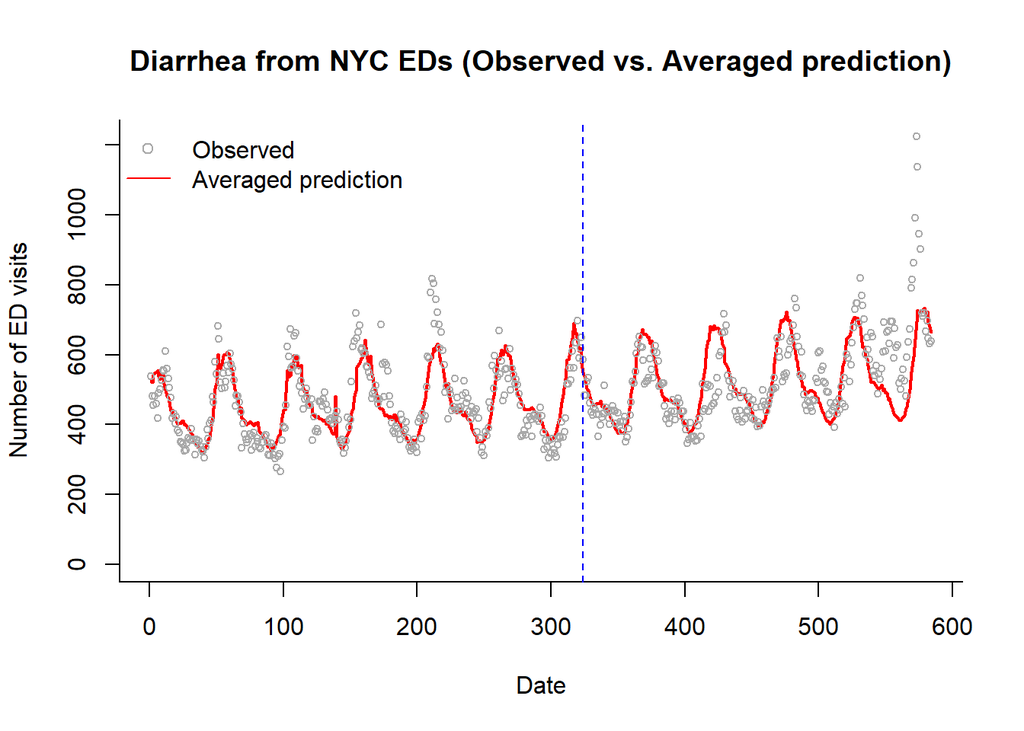

```r
# Create an empty matrix to store results
weighted.piece <- matrix(NA, nrow=nrow(model.preds), ncol=ncol(model.preds))

# Calculate "weighted" prediction
for(i in 1:ncol(weighted.piece)){
  weighted.piece[,i] <- model.preds[,i] * model.weights[i]
}

# Obtain averaged predictions
ave.pred <- rowSums(weighted.piece)

# Make a plot
plot(ave.pred, type='l', ylim=c(0,max( corr3$diar.18.64)), bty='l', ylab="Number of ED visits", xlab="Date", main="Diarrhea from NYC EDs (Observed vs. Averaged prediction)", col="red", lwd=2)
points(corr3$diar.18.64, cex=0.7, col="darkgrey")
abline(v=nrow(corr3)-260, lty=2, col="blue")
legend(x="topleft",legend = c("Observed","Averaged prediction"), pch=c(1, NA), lty=c(NA,1), col=c("darkgrey","red"), bty="n")
```